# Analyze: How do Casual Users and Annual Subscribers Differ?

Andrew Luyt 2021-07-27

## Quick descriptive statistics

```
## # A tibble: 14 × 3
## # Groups:   weekday [7]
##    weekday   member_casual n_rides
##    <fct>     <fct>           <int>
##  1 Monday    casual         210438
##  2 Monday    member         344378
##  3 Tuesday   casual         205153
##  4 Tuesday   member         372075
##  5 Wednesday casual         214006
##  6 Wednesday member         394318
##  7 Thursday  casual         215632
##  8 Thursday  member         375376
##  9 Friday    casual         280867
## 10 Friday    member         385044
## 11 Saturday  casual         458682
## 12 Saturday  member         399781
## 13 Sunday    casual         381370
## 14 Sunday    member         341135

## # A tibble: 2 × 6
##   member_casual trip_minutes_min trip_minutes_max trip_minutes_mean
##   <fct>                    <dbl>            <dbl>             <dbl>
## 1 casual                    1.02            1440.              35.7
## 2 member                    1.02            1440.              15.4
## # … with 2 more variables: trip_minutes_median <dbl>, trip_minutes_sd <dbl>
```

## Who rides most often?

Members take the majority of rides.

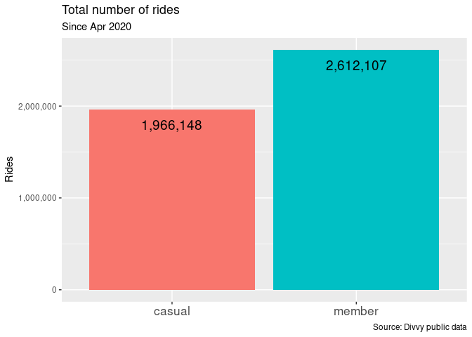

On weekends however, casual use approximately doubles and exceeds member use.

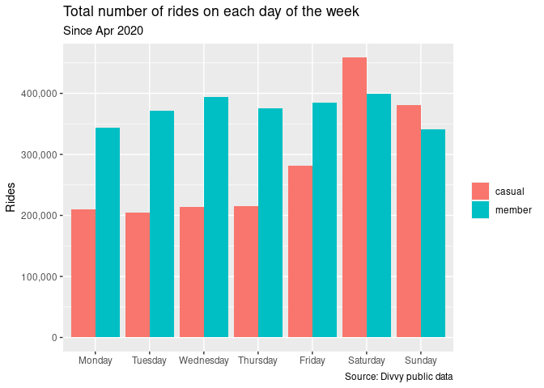

Breaking down the number of rides by month, we can see that while the season is important for all riders, casual users are much less willing to ride in the winter months. December to February, the system sees very little casual use.

[figure not shown]

## How do they differ on type of bike ridden?

Casuals are more likely to choose a docked bike and less likely to choose a classic bike.

**This is confusing**. The divvy website lists two types of bikes, **classic** and **electric bike.** What is a **docked bike**?

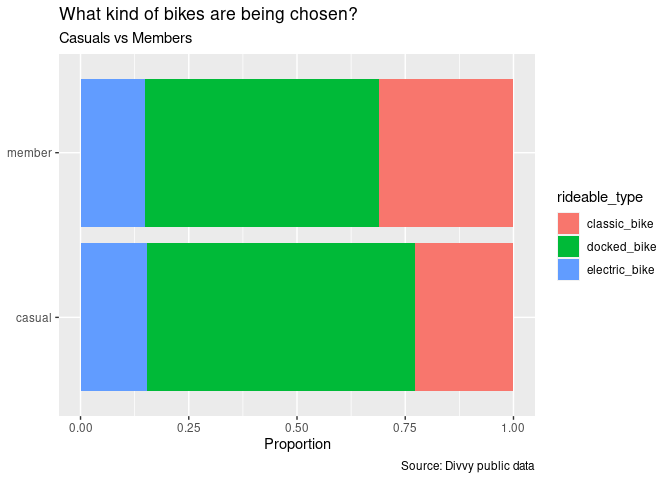

## How do trip distances vary?

This is a bit surprising - the average trip is about the same distance for both classes of users. For this analysis we’ve removed trips that start and end at the same station since we have no indication how long the trip was.

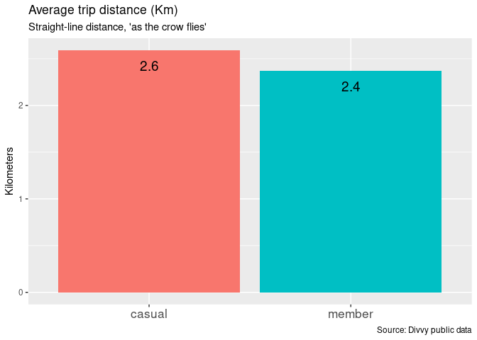

```r
df %>%
  filter(is_round_trip == 'a to b') %>%
  group_by(member_casual) %>%
  summarise(mean_trip_distance = mean(trip_distance)) %>%
  ggplot(aes(member_casual, mean_trip_distance, fill = member_casual)) +
  geom_col() +
  labs(title = "Average trip distance (Km)",
       subtitle = "Straight-line distance, 'as the crow flies'",
       caption = "Source: Divvy public data",
       x = NULL, y = "Kilometers") +
  geom_text(aes(label = round(mean_trip_distance, digits = 1)),
            vjust = 2.1,
            size = 5) +
  theme(legend.position = "none",
        axis.text.x = element_text(size = x.txt.size))
```

Not much difference by weekday.

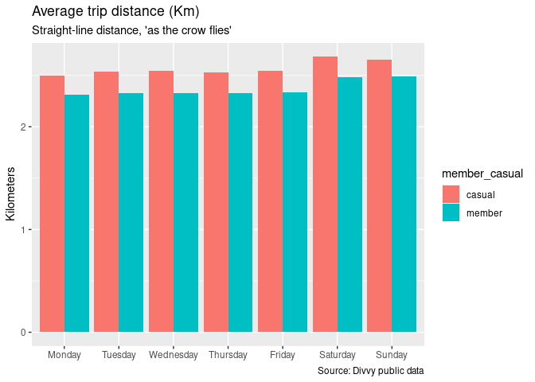

```r
df %>%
  filter(is_round_trip == 'a to b') %>%
  group_by(member_casual, weekday) %>%
  summarise(mean_trip_distance = mean(trip_distance)) %>%
  ggplot(aes(weekday, mean_trip_distance, fill = member_casual)) +
  geom_col(position = "dodge") +
  labs(title = "Average trip distance (Km)",
       subtitle = "Straight-line distance, 'as the crow flies'",
       caption = "Source: Divvy public data",
       x = NULL, y = "Kilometers")
```

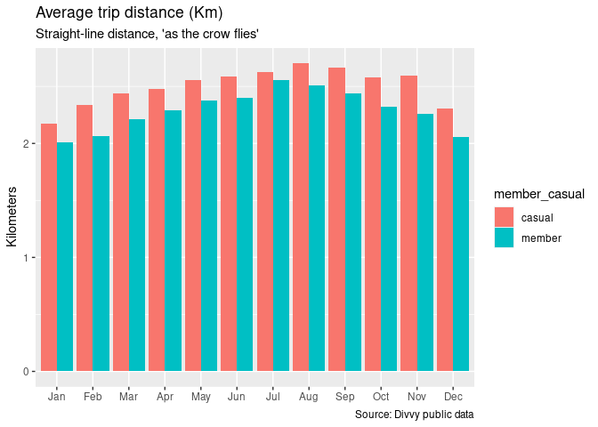

```r
df %>%
  filter(is_round_trip == 'a to b') %>%
  group_by(member_casual, month) %>%
  summarise(mean_trip_distance = mean(trip_distance)) %>%
  ggplot(aes(month, mean_trip_distance, fill = member_casual)) +
  geom_col(position = "dodge") +
  labs(title = "Average trip distance (Km)",
       subtitle = "Straight-line distance, 'as the crow flies'",
       caption = "Source: Divvy public data",
       x = NULL, y = "Kilometers")
```

For this analysis we’ve removed trips that start and end at the same station since they have an apparent distance of zero. We believe it’s likely that pleasure cruises make up a large portion of these rides. We’ll examine this idea in a section further below.

```r
df %>%
  filter(is_round_trip == 'round trip') %>%
  group_by(member_casual) %>%
  summarise("Possible pleasure cruises" = n(),
            "Avg trip minutes" = round(mean(trip_minutes), 0)) %>%
  rename("Rider Type" = member_casual)
```

```
## # A tibble: 2 × 3
##   `Rider Type` `Possible pleasure cruises` `Avg trip minutes`
##   <fct>                              <int>              <dbl>
## 1 casual                            315156                 61
## 2 member                            110279                 26
```

## How much *time* is spent on an average ride?

Casuals ride more than twice as long as members, on average. There isn’t much variation in ride duration over the week other than a slight increase over the weekend.

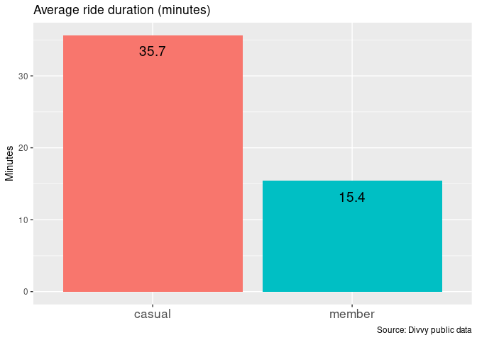

Seasonally, casual rides have a large amount of variation. The small number of winter trips taken tend to be short - half the length of rides at the peak of summer.

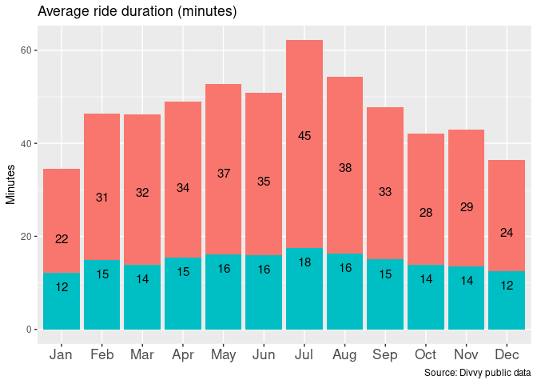

## Pleasure cruises?

Earlier we noted the possibility of about 10% of rides being round-trip pleasure cruises, starting and ending at the same station, likely near the rider’s home. The two graphs below provide evidence for this idea.

If our hypothesis is correct, the percentage of this type of ride should shrink in winter and grow in summer and be mostly confined to casual users. This first graph shows exactly this pattern.

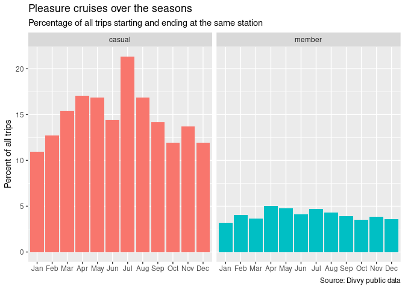

```r
df %>%
  group_by(month, member_casual, is_round_trip) %>%
  summarise(n = n()) %>%
  mutate(percent_of_rides = n / sum(n) * 100) %>%
  filter(is_round_trip == "round trip") %>%
  ggplot(aes(x = month, y = percent_of_rides, fill = member_casual)) +
  geom_col() +
  facet_wrap(~member_casual, ncol = 2) +
  labs(title = "Pleasure cruises over the seasons",
       subtitle = "Percentage of all trips starting and ending at the same station",
       caption = "Source: Divvy public data",
       x = NULL, y = "Percent of all trips") +
  theme(legend.position = "none")
```

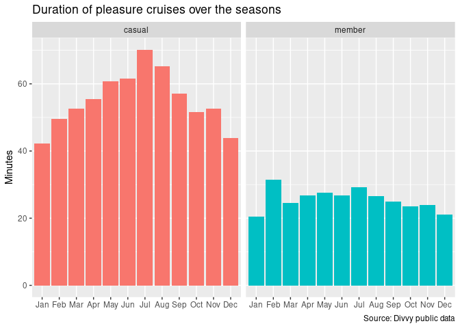

```r
df %>%
  group_by(month, member_casual, is_round_trip) %>%
  summarise(avg_ride_minutes = mean(trip_minutes)) %>%
  filter(is_round_trip == "round trip") %>%
  ggplot(aes(x = month, y = avg_ride_minutes, fill = member_casual)) +
  geom_col() +
  facet_wrap(~member_casual, ncol = 2) +
  labs(title = "Duration of pleasure cruises over the seasons",
       caption = "Source: Divvy public data",
       x = NULL, y = "Minutes") +
  theme(legend.position = "none")
```

## Ride speed

We’ve seen that casuals and members ride about the same distances, but members spend less time on the bikes. The graph below shows that members are about 30% faster on average.

We’ve removed trips that start and end at the same station, since their recorded trip distance is 0.

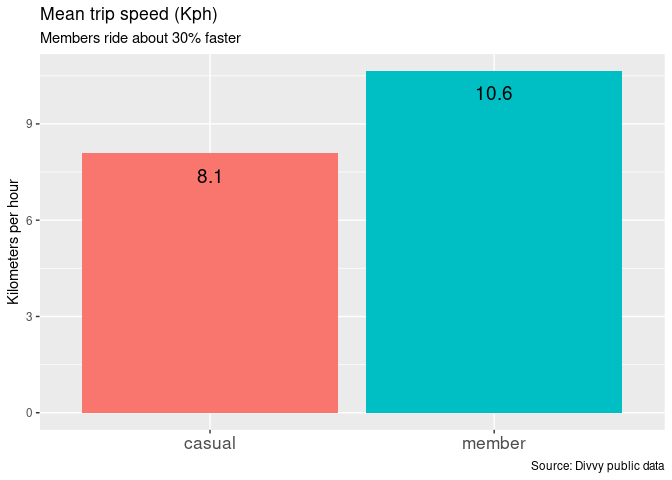

```r
df %>%
  filter(is_round_trip == 'a to b') %>%
  group_by(member_casual) %>%
  summarise(mean_kph = mean(trip_kph)) %>%
  ggplot(aes(member_casual, mean_kph, fill = member_casual)) +
  geom_col() +
  labs(title = "Mean trip speed (Kph)",
       subtitle = "Members ride about 30% faster",
       x = NULL, y = "Kilometers per hour",
       caption = "Source: Divvy public data") +
  geom_text(aes(label = round(mean_kph, digits = 1)),
            vjust = 2.1,
            size = 5) +
  theme(legend.position = "none",
        axis.text.x = element_text(size = x.txt.size))
```

## Members ride more often, casuals ride longer: who rides the most total minutes?

Casuals spend more time using the bicycles.

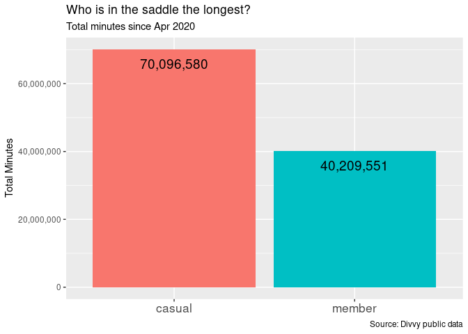

## What is the distribution of ride durations?

A quick examination shows a few notable items:

- Casuals have a higher mean and median trip time. i.e. they tend to take longer trips
- The difference is amplified in the particularly long trips
  - compare the 95th percentile trip time. 5% of casuals take trips longer than 1:50!

**NB: Divvy’s policies (starting in 2018) limit members to 45 minutes on the bike at one time (up from 30 minutes.) This artificial limit is almost certainly the cause of these observations. Anyone, members included, who wish a long cruise have to purchase a day pass.**

```
## # A tibble: 6 × 5
## # Groups:   member_casual [2]
##   member_casual  mean median quantiles     q
##   <fct>         <dbl>  <dbl>     <dbl> <dbl>
## 1 casual         35.7   20.9     11.6   0.25
## 2 casual         35.7   20.9     39.1   0.75
## 3 casual         35.7   20.9    108.    0.95
## 4 member         15.4   11.5      6.68  0.25
## 5 member         15.4   11.5     19.8   0.75
## 6 member         15.4   11.5     37.8   0.95
```

From above we see there is a **wide** range of trip lengths, with most being short and a small number being over an hour. We will trim off the longest 5% of trips so we can see the typical pattern of ride length.

**One observation is that casual riders make up almost all trips longer than 40 minutes.** Online research shows that in 2018, Divvy extended the maximum ride length for members to 45 minutes (up from 30). Longer rides incur a fee.

One question to arise from this: what sort of bike is most comfortable for long trips, and which are better for short ones? Do members tend to choose lighter, speedier bikes and do casuals prefer bikes with more comfort?

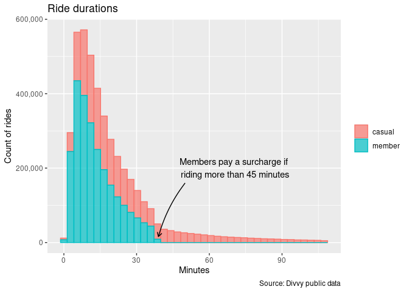

```r
df %>%
  group_by(member_casual) %>%  # IMPORTANT! Trim the top 5% of EACH GROUP, separately
  filter(trip_minutes < quantile(trip_minutes, 0.95)) %>%
  ungroup() %>%
  ggplot(aes(x = trip_minutes, fill = member_casual, color = member_casual)) +
  geom_histogram(bins = 40, alpha = 0.7) +
  scale_y_continuous(labels = scales::comma) +
  labs(title = "Ride durations",
       x = "Minutes", y = "Count of rides",
       caption = "Source: Divvy public data") +
  annotate(geom = "text", x = 70, y = 200000, label = "Members pay a surcharge if\n riding more than 45 minutes") +
  annotate(geom = "curve", x = 50, y = 160000, xend = 39, yend = 16000,
           curvature = 0.1, arrow = arrow(length = unit(.02, "npc"))) +
  theme(legend.title = element_blank())
```

## Ride duration, by weekday

We see an unsurprising distribution of trip durations over the week: a slight increase over the weekend, with casual riders having showing a larger difference.

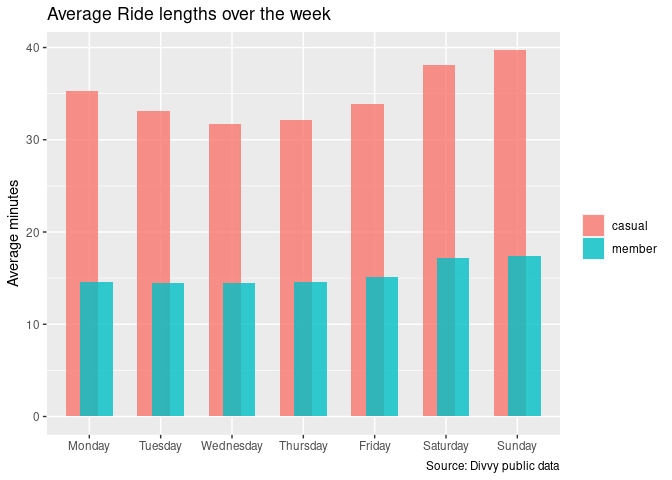

```r
df %>%
  group_by(weekday, member_casual) %>%
  summarise(mean_ride_length = mean(trip_minutes)) %>%
  ggplot(aes(weekday, mean_ride_length, fill=member_casual)) +
  geom_col(position = position_dodge(width = 0.4), alpha = 0.8) +
  labs(title = "Average Ride lengths over the week",
       x = NULL, y = "Average minutes",
       caption = "Source: Divvy public data") +
  theme(legend.title = element_blank())
```

## Number of trips by day of the week

We see here that:

- Member use is fairly steady through the week
- Casual use increases on Friday and nearly doubles through the weekend.

We can take this as more evidence that members are often commuting, whereas casuals are primarily riding for other reasons (enjoyment, exercise?)

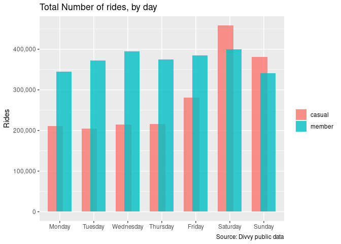

## Trips volume trend over the last year

- There is an enormous seasonal variation, from a low of 15 rides to a high of almost 20,000 in one day.
- The trend in 2021 is for higher volume than 2020
- Casual membership seems to be rising more sharply in 2021

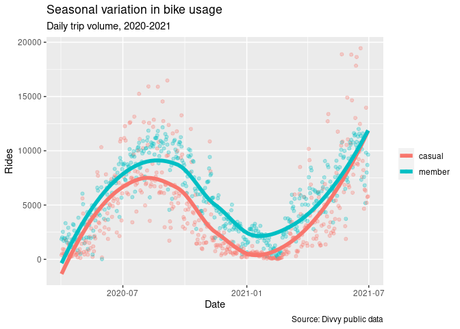

## Do weekends matter?

Yes, but only for casuals and not in winter.

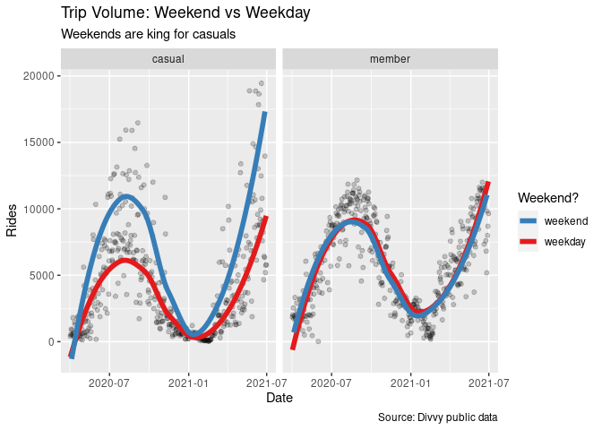

## Do they differ in *what hour* rides are taken?

Not much. There seems to be a slight tendency for casuals to start their rides later. The tendency is similar for ending times (not shown.)

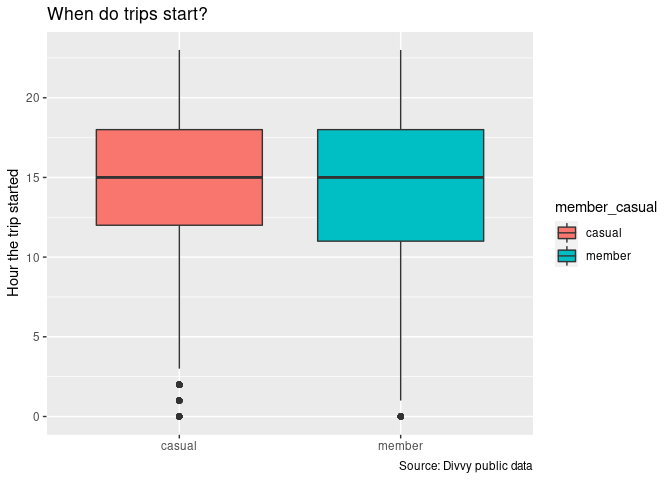

## Hour of trip start, in detail

Lending more weight to the ‘members commute more often’ hypothesis we see two jumps in member activity, both starting around morning and evening commute times. Casual users have a much smoother increase in trips as the day goes on. Two possible interpretations are that casuals are using a bike for their commute less often, or casual users tend to have non-typical start times for their job.

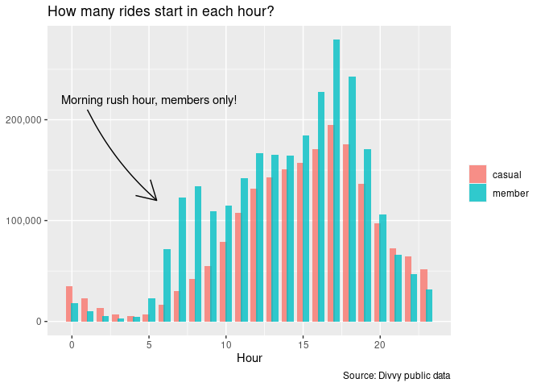

## Are some stations preferred by casuals?

Dramatically so! Some stations are 100% casual use and others are near-zero! The median station is 42% casual use.

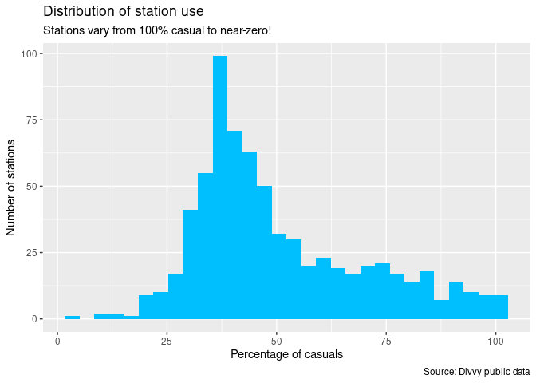

## Which stations do casuals use?

We’ll look at this question in two parts. **First** we’ll sort the stations by popularity (number of trips that start there) and colour the points by the proportion of the type of user. **Second** we will plot these stations on a map of Chicago.

**First**: station popularity. We can extract three main insights from the graph below:

- Overall, most stations are used primarily by members
- The least popular stations are dominated by casual use
- A few of the city’s most popular stations are over 75% casual use
  - These might make excellent targets for any pilot programs targeting casual users

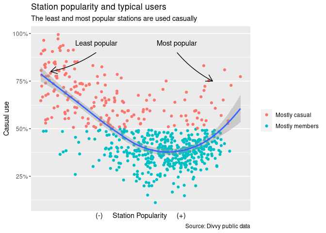

```r
df %>%
  group_by(start_station_id, member_casual) %>%
  summarise(n = n()) %>%
  mutate(total_trips = sum(n),
         p_casual = n / total_trips,
         mostly_casual = factor(p_casual > .5,
                                levels = c(TRUE, FALSE),
                                labels = c("Mostly casual", "Mostly members"))) %>%
  filter(member_casual == 'casual') %>%
  select(start_station_id, p_casual, total_trips, mostly_casual) %>%
  arrange(total_trips) %>%
  filter(total_trips > 100) %>% # remove nearly unused stations (some might be obsolete?)
  ggplot(aes(total_trips, p_casual)) +
  geom_point(aes(color = mostly_casual)) +
  geom_smooth() +
  scale_x_log10(breaks = NULL, name = "(-)     Station Popularity     (+)") +
  scale_y_continuous(labels = scales::percent) +
  annotate("text", x = 600, y = 0.95,
           label = "Least popular") +
  annotate("text", x = 8000, y = 0.95,
           label = "Most popular") +
  annotate("curve", x = 600, y = 0.9, xend = 140, yend=.8, curvature = -0.1,
           arrow = arrow(length = unit(0.04, "npc"))) +
  annotate("curve", x = 8000, y = 0.9, xend = 25000, yend=.75, curvature = 0.1,
           arrow = arrow(length = unit(0.04, "npc"))) +
  labs(title = "Station popularity and typical users",
       subtitle = "The least and most popular stations are used casually",
       y = "Casual use",
       caption = "Source: Divvy public data") +
  theme(legend.title = element_blank())
```

## Plot stations on the map

ideas:

- Size of dot varies with station popularity
- the colour varies with the proportion of users (by trip start) who are casuals.
  - First step: mostly_casual to colour the stations with binary scheme

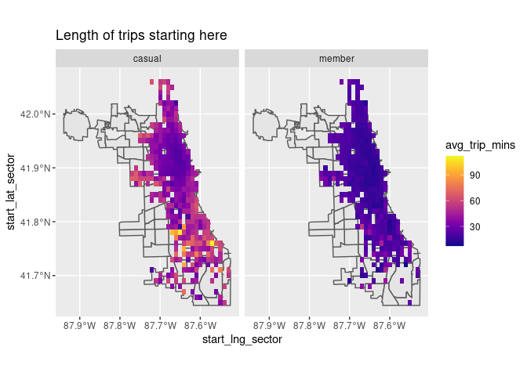

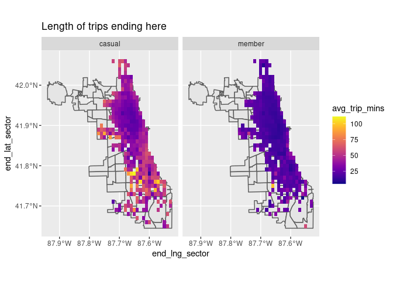

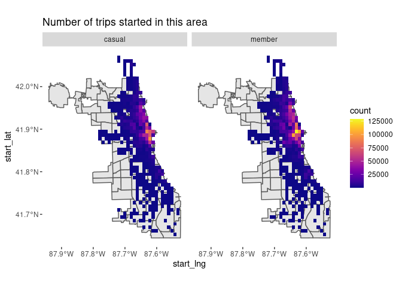

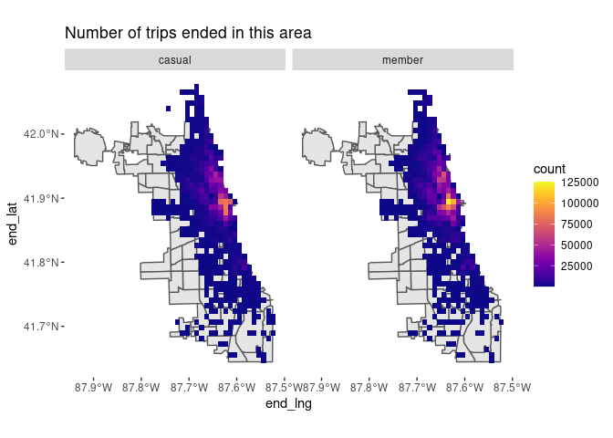

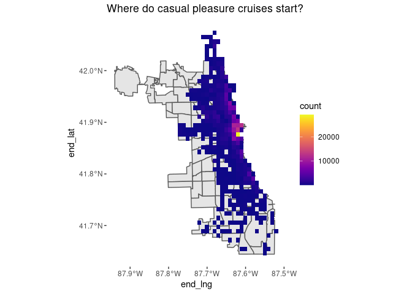

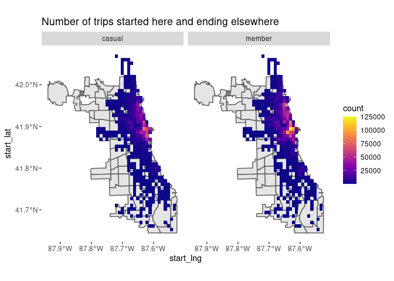

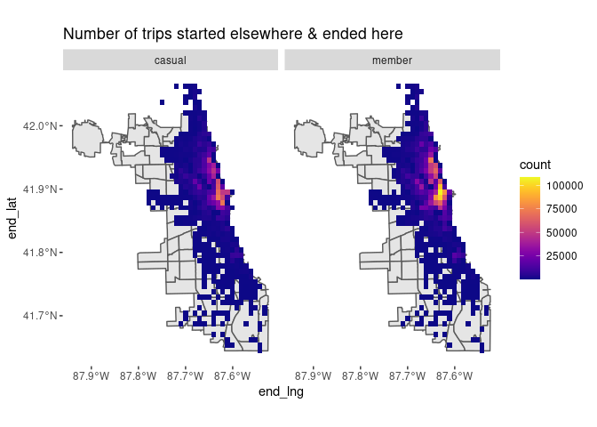

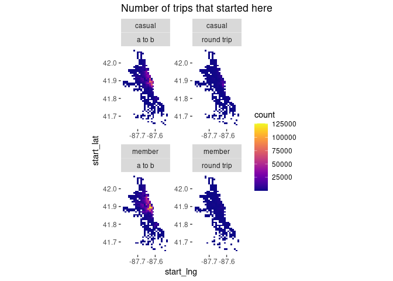

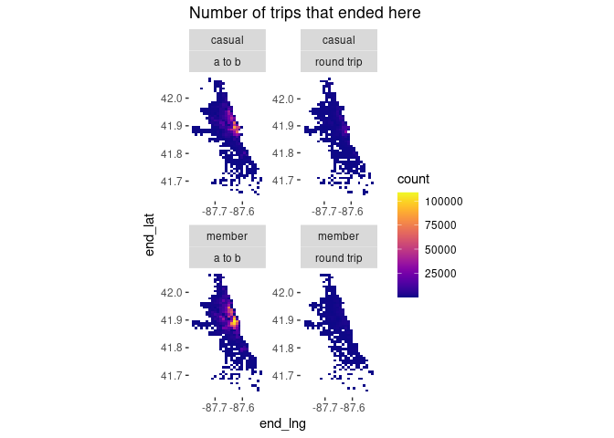